# Out of house data part2: machine learning

Mehmet Umut Caglar

9/25/2017

## Machine learning for out of house data (Part 2/2)

The out of house protein data is taken from: Schmidt, Alexander, et al. “The quantitative and condition-dependent Escherichia coli proteome.” Nature biotechnology 34.1 (2016): 104.

the first step is to load the processed external data

```r
meta_df1_Test = read.csv(file = "metaData1_ext.csv", row.names = 1)
testDataFrame1 = read.csv(file = "res_df1_ext.csv", row.names = 1)

meta_df2_Test = read.csv(file = "metaData2_ext.csv", row.names = 1)
testDataFrame2 = read.csv(file = "res_df2_ext.csv", row.names = 1)
```

The Second step is to load the results of tuning process. We run multiple tuning processes that have distinct labels. Here is the details of the tuning process used

```
##                                      [,1]
## pick_data                            "protein"
## sumTechRep                           "trT"
## bad_data_set                         "set00"
## experiment_names                     "StcYtcNasAgrNgrMgh"
## carbonSource_names                   "SYAN"
## MgLevel_names                        "baseMgAllMg"
## NaLevel_names                        "baseNaAllNa"
## growthPhase_names                    "ExpAllPhase"
## filter_Name                          "noMatchFilter"
## deSeqSfChoice                        "p1Sf"
## normalizationMethodChoice            "vst"
## numRepeatsFor_TestTrainSubset_Choice "60"
## percentTest                          "0.2"
## testConditions                       "Na_mM_Levels_Mg_mM_Levels_carbonSource_growthPhase"
## dimReductionType                     "PCA"
## batchCorrectionMethod                "fSVA"
## classWeightInputType                 "on SVA"
## similarDataClassifierForBatch        "Na_mM_Mg_mM_carbonSource_Short_growthPhase"
## type_svmChoice                       "C-classification"
## crossValue                           "10"
## nrepeatValue                         "1"
## samplingValue                        "cross"
## powerRangeGammaLow                   "-3"
## powerRangeGammaHigh                  "2"
## powerRangeCostLow                    "-1"
## powerRangeCostHigh                   "8"
## ndivision                            NA
## kernelList                           "linear_radial_sigmoid"
## ntreelistRF                          "1000_5000_10000"
## nodesizelistRF                       "1_2_3_4_5"
## mtrylistRF                           "1_2_3_4_5_6_7"
## batchCorrectionType                  "together"
## tuning                               "TRUE"
## parallel_com                         "TRUE"
## ncore                                "6"
## seedNo                               "14159"
## fileName                             "RunNo_2017_04_20_05_45_59_907834"
## ndivisionCost                        "55"
## ndivisionGamma                       "31"
## costFunction                         "F1_final"
## dimensionChoiceValue                 "10"
```

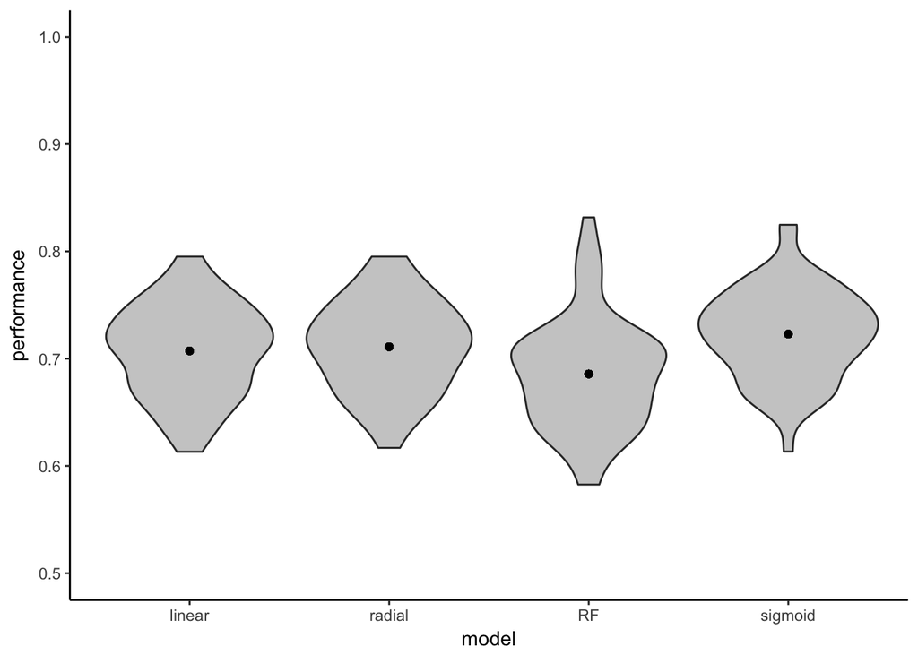

```r
# Load tuning results
model_performance = read.csv(file = "../b_results/model_performance_protein.csv")

fig01<-ggplot(model_performance, aes(x=model, y=performance, group=model))+
  geom_violin(fill="grey80")+
  geom_point(aes(x=model, y=meanPerformance))+
  theme_classic()+
  ylim(0.5,1)

print(fig01)
```

As can be seen from the figure **SVM with sigmoidal kernel** seems to be the best model

```r
model_performance %>%
  dplyr::filter(model == "radial") %>%
  dplyr::arrange(desc(performance)) %>%
  head(.)
```

```
##     X TestTrainSubsetNo  model performance        cost        gamma
## 1 104                44 radial   0.7951448  46415.8883 0.0010000000
## 2  92                32 radial   0.7913247 215443.4690 0.0010000000
## 3 106                46 radial   0.7895275   2154.4347 0.0464158883
## 4  82                22 radial   0.7766390  10000.0000 0.0068129207
## 5  87                27 radial   0.7667154    681.2921 0.0100000000
## 6  91                31 radial   0.7665238 316227.7660 0.0004641589
##   nodesize mtry ntree error_test performance_test meanPerformance
## 1       NA   NA    NA  0.7101190        0.2898810       0.7110418
## 2       NA   NA    NA  0.5342262        0.4657738       0.7110418
## 3       NA   NA    NA  0.6597222        0.3402778       0.7110418
## 4       NA   NA    NA  0.5332341        0.4667659       0.7110418
## 5       NA   NA    NA  0.6510417        0.3489583       0.7110418
## 6       NA   NA    NA  0.6349206        0.3650794       0.7110418
##   meanPerformance_test analyzeName
## 1            0.4879392     protein
## 2            0.4879392     protein
## 3            0.4879392     protein
## 4            0.4879392     protein
## 5            0.4879392     protein
## 6            0.4879392     protein
```

Now we need to load the protein data and train it with those parameters

```r
trainDataFrame = read.csv(file = "resDf_protein_trT_set00_StcYtcNasAgrNgrMgh_SYAN_baseMgAllMg_baseNaAllNa_ExpAllPhase_noMatchFilter_p1Sf_vst.csv",header = TRUE,row.names = 1)

load(file = paste0("../b_results/", chosenDataSetInfo$fileName, ".RDA"), verbose = TRUE)
```

```
## Loading objects:
##   timeStampVector
##   parallel_Result
##   factorOrder
##   factorOrder_Short
##   expandedGrid
##   expandedGrid_Short
##   vectorList
##   vectorList_Short
##   testConditions
##   inputMetaDf
```

```r
remove(timeStampVector, parallel_Result)

meta_df_Train = inputMetaDf

meta_df_Train %>%
  dplyr::select(dataSet, carbonSource, Mg_mM, Na_mM, growthTime_hr)
```

```
##      dataSet carbonSource Mg_mM Na_mM growthTime_hr
## 1   MURI_016      Glucose 8e-01     5           3.0
## 2   MURI_017      Glucose 8e-01     5           4.0
## 3   MURI_018      Glucose 8e-01     5           5.0
## 4   MURI_019      Glucose 8e-01     5           6.0
## 5   MURI_020      Glucose 8e-01     5           8.0
## 6   MURI_021      Glucose 8e-01     5          24.0
## 7   MURI_022      Glucose 8e-01     5          48.0
## 8   MURI_023      Glucose 8e-01     5         168.0
## 9   MURI_024      Glucose 8e-01     5         336.0
## 10  MURI_025      Glucose 8e-01     5           3.0
## 11  MURI_026      Glucose 8e-01     5           4.0
## 12  MURI_027      Glucose 8e-01     5           5.0
## 13  MURI_028      Glucose 8e-01     5           6.0
## 14  MURI_029      Glucose 8e-01     5           8.0
```

[output cut: 91 more lines]

Now we need to prepeare train and test datasets

Train data composes of all house data Test data is the all external data

We will do a 5+1 step procedure

- batch correction?? (may be later)
- Find the rows with 0 sd in training data, remove them from training and test data
- Find the missing rows on test data, replace them with the **median** values of training data
- Transpose data frames
- Do PCA (apply the rotation object to test data)
- Pick the first 10 rows

```r
# batchCorrDFs=batchCorrectSva(trainDataFrame_ = trainDataFrame,
#                              meta_df_Train_ = meta_df_Train,
#                              testDataFrame_ = testDataFrame,
#                              dataNameDF_ = dataNameDF)
#
# trainDataFrame = batchCorrDFs$trainDataFrame
# testDataFrame = batchCorrDFs$testDataFrame
```

```r
# 1. remove rows of 0 sd in training data from both training and test data
zerosdList=which(apply(trainDataFrame,1,sd)==0)
if(length(zerosdList)!=0){trainDataFrame=trainDataFrame[-zerosdList,]} # get rid of 0 sd data
if(length(zerosdList)!=0){testDataFrame1=testDataFrame1[-zerosdList,]} # get rid of 0 sd data
if(length(zerosdList)!=0){testDataFrame2=testDataFrame2[-zerosdList,]} # get rid of 0 sd data
```

```r
# 2.a.dataSet1 Find the missing rows on test data, replace them with the median values of training data
theMedianList1 = setdiff(row.names(trainDataFrame), row.names(testDataFrame1))
trainDataFrame %>%
  tibble::rownames_to_column(var = "rowNames") %>%
  dplyr::filter(rowNames %in% theMedianList1) %>%
  tibble::column_to_rownames(var = "rowNames") -> trainDataFrame1_missing

missing_medians1 <-apply(trainDataFrame1_missing, 1, median) # row medians

foo <- data.frame(glucose = missing_medians1,
                  glycerol = missing_medians1,
                  Na_50_stress = missing_medians1,
                  stationary = missing_medians1,
                  late_stationary = missing_medians1)
row.names(foo) <- names(missing_medians1)

rbind(testDataFrame1, foo) %>%
  tibble::rownames_to_column(var = "rowNames") %>%
  dplyr::arrange(rowNames) %>%
  tibble::column_to_rownames(var = "rowNames") -> testDataFrame1_expanded


# 2.b.dataSet1 Alternative way. Get rid of the missing data in training set (The other way is higly biased)
theMedianList1 = setdiff(row.names(trainDataFrame), row.names(testDataFrame1))
trainDataFrame %>%
  tibble::rownames_to_column(var = "rowNames") %>%
  dplyr::filter(!rowNames %in% theMedianList1) %>%
  tibble::column_to_rownames(var = "rowNames") -> trainDataFrame1_shrunken
# this alternative removes samples from tarining which might prevent bias





# 2.a.dataSet2 Find the missing rows on test data, replace them with the median values of training data
theMedianList2 = setdiff(row.names(trainDataFrame), row.names(testDataFrame2))
trainDataFrame %>%
  tibble::rownames_to_column(var = "rowNames") %>%
  dplyr::filter(rowNames %in% theMedianList2) %>%
  tibble::column_to_rownames(var = "rowNames") -> trainDataFrame2_missing

missing_medians2 <-apply(trainDataFrame2_missing, 1, median) # row medians

foo <- data.frame(glucose = missing_medians2,
                  glycerol = missing_medians2,
                  Na_50_stress = missing_medians2,
                  stationary = missing_medians2,
                  late_stationary = missing_medians2)
row.names(foo) <- names(missing_medians2)

rbind(testDataFrame2, foo) %>%
  tibble::rownames_to_column(var = "rowNames") %>%
  dplyr::arrange(rowNames) %>%
  tibble::column_to_rownames(var = "rowNames") -> testDataFrame2_expanded


# 2.b.dataSet1 Alternative way. Get rid of the missing data in training set (The other way is higly biased)
theMedianList2 = setdiff(row.names(trainDataFrame), row.names(testDataFrame2))
trainDataFrame %>%
  tibble::rownames_to_column(var = "rowNames") %>%
  dplyr::filter(!rowNames %in% theMedianList2) %>%
  tibble::column_to_rownames(var = "rowNames") -> trainDataFrame2_shrunken
# this alternative removes samples from tarining which might prevent bias
```

```r
# 3.a.dataset1 Transpose Data Frames (expand)
trainDataFrame1 <- t(trainDataFrame)
testDataFrame1_expanded <- t(testDataFrame1_expanded)

# 3.b.dataset1 Transpose Data Frames (shrink)
trainDataFrame1_shrunken <- t(trainDataFrame1_shrunken)
testDataFrame1 <- t(testDataFrame1)


# 3.a.dataset2 Transpose Data Frames (expand)
trainDataFrame2 <- t(trainDataFrame)
testDataFrame2_expanded <- t(testDataFrame2_expanded)

# 3.b.dataset2 Transpose Data Frames (shrink)
trainDataFrame2_shrunken <- t(trainDataFrame2_shrunken)
testDataFrame2 <- t(testDataFrame2)
```

```r
# 4.a.dataset1 PCA (expand)
mapped_DF_Objs1_expanded=pca_analyze(train_set = trainDataFrame1,
                                     train_condition = meta_df_Train,
                                     test_set = testDataFrame1_expanded,
                                     test_condition = meta_df1_Test)
mapped_train_DF1 <- mapped_DF_Objs1_expanded$train_set_PCs_comb
mapped_expanded_test_DF1 <- mapped_DF_Objs1_expanded$test_set_PCs_comb

# 4.b.dataset1 PCA (shrink)

mapped_DF_Objs1_shrunken=pca_analyze(train_set = trainDataFrame1_shrunken,
                                     train_condition = meta_df_Train,
                                     test_set = testDataFrame1,
                                     test_condition = meta_df1_Test)
mapped_shrunken_train_DF1 <- mapped_DF_Objs1_shrunken$train_set_PCs_comb
mapped_test_DF1 <- mapped_DF_Objs1_shrunken$test_set_PCs_comb






# 4.a.dataset2 PCA (expand)
mapped_DF_Objs2_expanded=pca_analyze(train_set = trainDataFrame2,
                                     train_condition = meta_df_Train,
                                     test_set = testDataFrame2_expanded,
                                     test_condition = meta_df2_Test)
mapped_train_DF2 <- mapped_DF_Objs2_expanded$train_set_PCs_comb
mapped_expanded_test_DF2 <- mapped_DF_Objs2_expanded$test_set_PCs_comb

# 4.b.dataset2 PCA (shrink)

mapped_DF_Objs2_shrunken=pca_analyze(train_set = trainDataFrame2_shrunken,
                                     train_condition = meta_df_Train,
                                     test_set = testDataFrame2,
                                     test_condition = meta_df2_Test)
mapped_shrunken_train_DF2 <- mapped_DF_Objs2_shrunken$train_set_PCs_comb
mapped_test_DF2 <- mapped_DF_Objs2_shrunken$test_set_PCs_comb
```

```r
###*****************************
# 5. Pick the first dimensions
# Pick # of dimensions that needs to go into machine learning algorithm
dimensionChoice=dimensionChoiceValue

# generate the list of dimensions that will be selected from df by using dplyr::select
selectList = c("conditionInvestigated",paste0("Axis.",seq(1,dimensionChoice)))
selectList1 = intersect(selectList, colnames(mapped_train_DF1))
selectList2 = intersect(selectList, colnames(mapped_train_DF2))

# selection of wanted dimensions with dplyr::select for "mapped_train_DF" and "mapped_expanded_test_DF" for expended datasets
mapped_train_DF1 %>%
  tibble::column_to_rownames(var = "dataSet")%>%
  dplyr::select_(.dots = selectList1)->dim_reduced_train_DF1

mapped_train_DF2 %>%
  tibble::column_to_rownames(var = "dataSet")%>%
  dplyr::select_(.dots = selectList2)->dim_reduced_train_DF2

mapped_expanded_test_DF1 %>%
  tibble::column_to_rownames(var = "dataSet")%>%
  dplyr::select_(.dots = selectList1) %>%
  dplyr::group_by()%>%
  dplyr::select(-conditionInvestigated)->dim_reduced_expanded_test_DF1

mapped_expanded_test_DF2 %>%
  tibble::column_to_rownames(var = "dataSet")%>%
  dplyr::select_(.dots = selectList2) %>%
  dplyr::group_by()%>%
  dplyr::select(-conditionInvestigated)->dim_reduced_expanded_test_DF2

print(head(dim_reduced_train_DF1))
```

```
##                        conditionInvestigated    Axis.1   Axis.2    Axis.3
## MURI_016 Base Na_Base Mg_Glucose_Exponential -25.85513 22.71285 -21.76877
## MURI_017 Base Na_Base Mg_Glucose_Exponential -24.98015 22.66538 -23.11787
## MURI_018 Base Na_Base Mg_Glucose_Exponential -24.20917 20.33037 -27.34288
## MURI_019 Base Na_Base Mg_Glucose_Exponential -24.63699 18.99761 -27.79729
## MURI_020 Base Na_Base Mg_Glucose_Exponential -23.25894 18.69059 -27.21805
## MURI_021  Base Na_Base Mg_Glucose_Stationary -23.64912 20.68650 -22.74326
##              Axis.4    Axis.5     Axis.6      Axis.7    Axis.8     Axis.9
## MURI_016  11.612130 -7.758867  4.8400624 -1.37369204 2.9594723 -1.1418629
## MURI_017  14.450094 -7.863903  2.6875106 -2.70814512 2.7183337  0.1909538
## MURI_018  14.494589 -8.575713  1.5422689 -1.33358572 4.1987883  0.4442072
## MURI_019  13.630416 -8.716006  1.5474942 -0.06720645 2.5824865 -0.1048725
## MURI_020   3.709293 -7.509926  0.2950309  2.12941347 3.6120551  0.3800503
## MURI_021 -20.850794 -4.781770 -0.2704462  5.24605499 0.4830295 -3.5569032
##             Axis.10
## MURI_016  4.2892945
## MURI_017  4.0881759
## MURI_018  1.6953805
## MURI_019  0.5099668
## MURI_020 -2.7116625
## MURI_021 -1.3791951
```

```r
print(head(dim_reduced_expanded_test_DF1))
```

```
## # A tibble: 5 x 10
##   Axis.1 Axis.2 Axis.3 Axis.4 Axis.5 Axis.6 Axis.7 Axis.8 Axis.9 Axis.10
##    <dbl>  <dbl>  <dbl>  <dbl>  <dbl>  <dbl>  <dbl>  <dbl>  <dbl>   <dbl>
## 1  -31.1   84.9   15.3 - 6.91   13.6 -10.2   -17.0 -0.690  2.81   -4.56
## 2  -30.9   83.5   18.5 -11.1    10.5 - 8.94  -15.2 -1.95   4.06   -5.68
## 3  -34.0   85.0   15.2 - 7.16   14.9 -10.00  -16.8 -1.80   3.14   -4.79
## 4  -25.1   85.4   17.2 -19.0    16.6 -12.7   -23.3  0.394 -0.513  -1.29
## 5  -26.4   84.2   17.9 -19.7    17.4 -12.7   -22.4  0.523  0.751  -0.394
```

```r
print(head(dim_reduced_train_DF2))
```

```
##                        conditionInvestigated    Axis.1   Axis.2    Axis.3
## MURI_016 Base Na_Base Mg_Glucose_Exponential -25.85513 22.71285 -21.76877
## MURI_017 Base Na_Base Mg_Glucose_Exponential -24.98015 22.66538 -23.11787
## MURI_018 Base Na_Base Mg_Glucose_Exponential -24.20917 20.33037 -27.34288
## MURI_019 Base Na_Base Mg_Glucose_Exponential -24.63699 18.99761 -27.79729
## MURI_020 Base Na_Base Mg_Glucose_Exponential -23.25894 18.69059 -27.21805
## MURI_021  Base Na_Base Mg_Glucose_Stationary -23.64912 20.68650 -22.74326
##              Axis.4    Axis.5     Axis.6      Axis.7    Axis.8     Axis.9
## MURI_016  11.612130 -7.758867  4.8400624 -1.37369204 2.9594723 -1.1418629
## MURI_017  14.450094 -7.863903  2.6875106 -2.70814512 2.7183337  0.1909538
## MURI_018  14.494589 -8.575713  1.5422689 -1.33358572 4.1987883  0.4442072
## MURI_019  13.630416 -8.716006  1.5474942 -0.06720645 2.5824865 -0.1048725
## MURI_020   3.709293 -7.509926  0.2950309  2.12941347 3.6120551  0.3800503
## MURI_021 -20.850794 -4.781770 -0.2704462  5.24605499 0.4830295 -3.5569032
##             Axis.10
## MURI_016  4.2892945
## MURI_017  4.0881759
## MURI_018  1.6953805
## MURI_019  0.5099668
## MURI_020 -2.7116625
## MURI_021 -1.3791951
```

```r
print(head(dim_reduced_expanded_test_DF2))
```

```
## # A tibble: 5 x 10
##   Axis.1 Axis.2 Axis.3  Axis.4 Axis.5 Axis.6 Axis.7 Axis.8 Axis.9 Axis.10
##    <dbl>  <dbl>  <dbl>   <dbl>  <dbl>  <dbl>  <dbl>  <dbl>  <dbl>   <dbl>
## 1  -50.1    114   15.3 - 0.200   23.2  -18.3  -20.9  -21.3  4.19    -8.03
## 2  -48.8    114   19.7 - 4.61    18.9  -18.4  -20.4  -22.7  4.79    -9.29
## 3  -48.5    115   14.0 - 6.31    25.1  -20.0  -22.0  -19.6  2.20    -9.45
## 4  -47.1    113   17.4 -15.8     25.0  -20.6  -18.6  -22.2  0.500   -7.74
## 5  -46.6    112   17.2 -16.9     26.2  -21.3  -18.4  -22.1  0.338   -7.13
```

```r
# selection of wanted dimensions with dplyr::select for "mapped_shrunken_train_DF" and "mapped_test_DF" for shrank data sets
mapped_shrunken_train_DF1 %>%
  tibble::column_to_rownames(var = "dataSet")%>%
  dplyr::select_(.dots = selectList1)->dim_reduced_shrunken_train_DF1

mapped_shrunken_train_DF2 %>%
  tibble::column_to_rownames(var = "dataSet")%>%
  dplyr::select_(.dots = selectList2)->dim_reduced_shrunken_train_DF2

mapped_test_DF1 %>%
  tibble::column_to_rownames(var = "dataSet")%>%
  dplyr::select_(.dots = selectList1) %>%
  dplyr::group_by()%>%
  dplyr::select(-conditionInvestigated)->dim_reduced_test_DF1

mapped_test_DF2 %>%
  tibble::column_to_rownames(var = "dataSet")%>%
  dplyr::select_(.dots = selectList2) %>%
  dplyr::group_by()%>%
  dplyr::select(-conditionInvestigated)->dim_reduced_test_DF2


# Print the results
print(head(dim_reduced_shrunken_train_DF1))
```

```
##                        conditionInvestigated    Axis.1    Axis.2   Axis.3
## MURI_016 Base Na_Base Mg_Glucose_Exponential -26.64867 -2.328395 14.13629
## MURI_017 Base Na_Base Mg_Glucose_Exponential -26.58568 -4.167737 16.95143
## MURI_018 Base Na_Base Mg_Glucose_Exponential -24.72367 -5.793111 18.43353
## MURI_019 Base Na_Base Mg_Glucose_Exponential -24.41024 -7.024500 17.67830
## MURI_020 Base Na_Base Mg_Glucose_Exponential -23.94036 -6.210929 10.68636
## MURI_021  Base Na_Base Mg_Glucose_Stationary -25.47822 -1.632586 -7.86557
##             Axis.4   Axis.5      Axis.6     Axis.7     Axis.8      Axis.9
## MURI_016 -10.16590 6.453360 -2.65887711  2.5597970 -1.2199936  0.04410329
## MURI_017 -10.46862 5.803685 -1.33169413  3.2715259 -1.5334369 -0.14992614
## MURI_018 -12.16545 6.350684 -0.77991190  2.1582912 -2.9730840 -0.55350100
## MURI_019 -12.51484 5.304003 -0.92522157  1.2299993 -1.7402931 -0.23602466
## MURI_020 -15.01225 4.288807  0.06025151 -1.1218503 -2.3752369  0.29940790
## MURI_021 -21.03435 1.693651  0.72497937 -0.5293673 -0.3069294  4.24698032
##             Axis.10
## MURI_016 -3.0790828
## MURI_017 -3.1906692
## MURI_018 -1.2495572
## MURI_019 -0.3006869
## MURI_020  2.6236400
## MURI_021  0.6159152
```

```r
print(head(dim_reduced_test_DF1))
```

```
## # A tibble: 5 x 10
##   Axis.1 Axis.2  Axis.3 Axis.4 Axis.5 Axis.6 Axis.7 Axis.8 Axis.9 Axis.10
##    <dbl>  <dbl>   <dbl>  <dbl>  <dbl>  <dbl>  <dbl>  <dbl>  <dbl>   <dbl>
## 1  -86.8   80.5 - 0.958   2.10  -17.7   36.8   28.7   15.5  -13.1    16.4
## 2  -85.4   80.3 - 7.81    3.80  -13.4   34.2   25.5   15.5  -13.3    18.0
## 3  -89.9   75.2 - 2.28    3.58  -18.7   33.5   27.9   15.2  -13.5    15.3
## 4  -81.4   92.3 -13.7    -4.93  -23.8   48.6   45.0   17.4  -12.7    11.6
## 5  -81.7   88.7 -15.6    -3.31  -24.5   46.6   43.4   15.7  -12.5    10.5
```

```r
print(head(dim_reduced_shrunken_train_DF2))
```

```
##                        conditionInvestigated    Axis.1    Axis.2
## MURI_016 Base Na_Base Mg_Glucose_Exponential -27.92419 -3.016033
## MURI_017 Base Na_Base Mg_Glucose_Exponential -27.94693 -4.489157
## MURI_018 Base Na_Base Mg_Glucose_Exponential -25.98263 -6.240084
## MURI_019 Base Na_Base Mg_Glucose_Exponential -25.50078 -6.684498
## MURI_020 Base Na_Base Mg_Glucose_Exponential -24.73968 -7.239678
## MURI_021  Base Na_Base Mg_Glucose_Stationary -26.24650 -3.250705
##              Axis.3    Axis.4    Axis.5     Axis.6     Axis.7     Axis.8
## MURI_016  12.855170 -11.86327 7.4730063 -2.6812024  0.4990839 -3.0661777
## MURI_017  15.669960 -12.07595 7.0429101 -0.9571260  0.4246288 -3.4268021
## MURI_018  17.210882 -14.28555 7.2091018 -0.2466830 -1.4510490 -3.0312523
## MURI_019  17.116516 -15.53870 6.6906095 -0.1274368 -0.6428001 -2.2047718
## MURI_020   8.988026 -17.12277 5.7636021  0.6879488 -2.3402986 -0.5276933
## MURI_021 -10.862877 -20.80895 0.5459135 -0.1345190 -0.1275485  0.6074940
##              Axis.9    Axis.10
## MURI_016  0.2406796 -4.1867487
## MURI_017  0.2579059 -3.9211345
## MURI_018  0.1472023 -1.0979129
## MURI_019 -0.3891815  0.6192297
## MURI_020  0.7716274  3.3227733
## MURI_021  3.7022923  1.0059153
```

```r
print(head(dim_reduced_test_DF2))
```

```
## # A tibble: 5 x 10
##   Axis.1 Axis.2  Axis.3 Axis.4 Axis.5 Axis.6 Axis.7 Axis.8 Axis.9 Axis.10
##    <dbl>  <dbl>   <dbl>  <dbl>  <dbl>  <dbl>  <dbl>  <dbl>  <dbl>   <dbl>
## 1   -125   75.5   6.10    9.70  -17.4   38.7   46.8 -0.560  -5.00    19.7
## 2   -123   78.8 - 0.812  12.4   -12.4   39.8   46.6  1.85   -5.21    22.2
## 3   -124   78.5   0.328   4.28  -21.8   43.0   50.9 -3.26   -6.21    22.0
## 4   -121   79.8 -12.0     4.42  -23.4   43.4   50.6  1.69   -2.48    18.4
## 5   -120   79.9 -13.1     3.68  -25.2   44.5   50.9  1.79   -2.56    17.4
```

```r
###*****************************
```

The last step is to calculate the weight vectors; they are basically inversely proportional to the umber of samples for each category.

```r
# Dataset1
meta_df_Train %>%
  dplyr::group_by(conditionInvestigated) %>%
  dplyr::summarize(numSample = n()) %>%
  dplyr::mutate(invNumSample = 1/numSample) %>%
  dplyr::mutate(weight = invNumSample / sum(invNumSample)) -> classWeights

weightVector <- classWeights$weight
names(weightVector) <- classWeights$conditionInvestigated


# Print the results
print(head(classWeights))
```

```
## # A tibble: 6 x 4
##   conditionInvestigated                 numSample invNumSample weight
##   <fct>                                     <int>        <dbl>  <dbl>
## 1 Base Na_Low Mg_Glucose_Exponential            3       0.333  0.0978
## 2 Base Na_Base Mg_Glucose_Exponential          20       0.0500 0.0147
## 3 High Na_Base Mg_Glucose_Exponential           6       0.167  0.0489
## 4 Base Na_High Mg_Glucose_Exponential           6       0.167  0.0489
## 5 Base Na_Base Mg_Glycerol_Exponential         15       0.0667 0.0196
## 6 Base Na_Base Mg_Gluconate_Exponential         3       0.333  0.0978
```

## Learn the model

Its time to train the model

```r
# Learn from Dataset 1 with expanded data
modelSVM_expanded_sigmoid1 <- e1071::svm(data = dim_reduced_train_DF1 ,
                                         conditionInvestigated~.,
                                         type = "C-classification",
                                         kernel = "sigmoid",
                                         class.weights = weightVector,
                                         cost=251,
                                         gamma = 1)

# Learn from Dataset 2 with expanded data
modelSVM_expanded_sigmoid2 <- e1071::svm(data = dim_reduced_train_DF2 ,
                                         conditionInvestigated~.,
                                         type = "C-classification",
                                         kernel = "sigmoid",
                                         class.weights = weightVector,
                                         cost=251,
                                         gamma = 1)

# make prediction with the model (Dataset 1 expanded data)
modelSVM_expanded_sigmoid1 %>%
  predict(.,dim_reduced_expanded_test_DF1) %>%
  data.frame(predictedValue = .)
```

```
##                                       predictedValue
## glucose           Base Na_Base Mg_Lactate_Stationary
## glycerol          Base Na_Base Mg_Lactate_Stationary
## Na_50_stress      Base Na_Base Mg_Lactate_Stationary
## stationary        Base Na_Base Mg_Lactate_Stationary
## late_stationary Base Na_Base Mg_Gluconate_Stationary
```

```r
# make prediction with the model (Dataset 2 expanded data)
modelSVM_expanded_sigmoid2 %>%
  predict(.,dim_reduced_expanded_test_DF2) %>%
  data.frame(predictedValue = .)
```

```
##                                        predictedValue
## glucose         Base Na_Base Mg_Gluconate_Exponential
## glycerol           Base Na_Base Mg_Lactate_Stationary
## Na_50_stress       Base Na_Base Mg_Lactate_Stationary
## stationary         Base Na_Base Mg_Lactate_Stationary
## late_stationary    Base Na_Base Mg_Lactate_Stationary
```

```r
# Learn from Dataset 1 with shrunken data
modelSVM_shrunken_sigmoid1 <- e1071::svm(data = dim_reduced_shrunken_train_DF1,
                                         conditionInvestigated~.,
                                         type = "C-classification",
                                         kernel = "sigmoid",
                                         class.weights = weightVector,
                                         cost=251,
                                         gamma = 1)

# Learn from Dataset 2 with shrunken data
modelSVM_shrunken_sigmoid2 <- e1071::svm(data = dim_reduced_shrunken_train_DF2,
                                         conditionInvestigated~.,
                                         type = "C-classification",
                                         kernel = "sigmoid",
                                         class.weights = weightVector,
                                         cost=251,
                                         gamma = 1)

# make prediction with the model (Dataset1 shrunken data)
modelSVM_shrunken_sigmoid1 %>%
  predict(.,dim_reduced_test_DF1) %>%
  data.frame(predictedValue = .)
```

```
##                                      predictedValue
## glucose          High Na_Base Mg_Glucose_Stationary
## glycerol        High Na_Base Mg_Glucose_Exponential
## Na_50_stress     High Na_Base Mg_Glucose_Stationary
## stationary      High Na_Base Mg_Glucose_Exponential
## late_stationary High Na_Base Mg_Glucose_Exponential
```

```r
# make prediction with the model (Dataset2 shrunken data)
modelSVM_shrunken_sigmoid2 %>%
  predict(.,dim_reduced_test_DF2) %>%
  data.frame(predictedValue = .)
```

```
##                                        predictedValue
## glucose         Base Na_Base Mg_Gluconate_Exponential
## glycerol        Base Na_Base Mg_Gluconate_Exponential
## Na_50_stress       High Na_Base Mg_Glucose_Stationary
## stationary         Base Na_Base Mg_Glucose_Stationary
## late_stationary    Base Na_Base Mg_Glucose_Stationary
```